# Neural Network and Deep Learning (Introduction)

### 11.2 Dropout learning

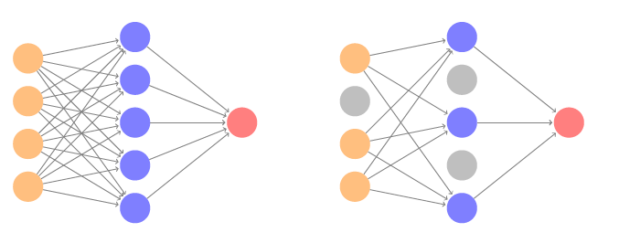

Figure 13: Dropout Learning. Left: a fully connected network. Right: network with dropout in the input and hidden layer. The nodes in grey are selected at random, and ignored in an instance of training.

- At each SGD update, **drop** each unit with probability $\phi$ (so the **keep probability** is $q = 1-\phi$). For the units that are kept, scale their activations (equivalently their outgoing weights) by $1/q$ (“inverted dropout”) so that the overall signal level is comparable between training and test.
- More explicitly, if $a^{(\ell)}\in\mathbb{R}^{H_\ell}$ denotes the vector of activations entering layer $\ell$, draw a random mask $m^{(\ell)}\in\{0,1\}^{H_\ell}$ with independent components $m^{(\ell)}_j\sim\text{Bernoulli}(q)$, and use
  $$\tilde a^{(\ell)} = \frac{m^{(\ell)}}{q} \odot a^{(\ell)},$$
  where $\odot$ denotes elementwise multiplication.
- The scaling by $1/q$ ensures that the *expected* activation is unchanged:
  $$\mathbb{E}[\tilde a^{(\ell)}] = a^{(\ell)}.$$
  At **test time**, we use the full network without masking (i.e. replace $\tilde a^{(\ell)}$ by $a^{(\ell)}$).
- Interpretation: each minibatch update trains a different “thinned” subnetwork; prediction with the full network approximates averaging an ensemble of many subnetworks (a form of **model averaging**).
- More broadly, dropout injects **multiplicative Bernoulli noise** and often behaves like an $\ell_2$-type shrinkage of weights; the exact equivalence is cleanest for squared-loss linear models (as above), while for deep nets it is better viewed as regularization via model averaging and reduced co-adaptation.
- As in ridge, the other units **stand** in for those temporarily removed, and their weights are drawn closer together.
- Similar to randomly omitting variables when growing trees in random forests.

### 11.3 Ridge and data augmentation

- Make many copies of each $(x_i, y_i)$ and add a small amount of Gaussian noise to the $x_i$, a little cloud around each observation, but leave the copies of $y_i$ alone!
- This makes the fit robust to small perturbations in $x_i$, and is equivalent to ridge regularization in an OLS setting.
- Data augmentation is especially effective with SGD. Natural transformations are made of each training image when it is sampled by SGD, thus ultimately making a cloud of images around each original training image.
- The label is left unchanged, in each case still `tiger`.
- Improves performance of CNN and is similar to ridge.

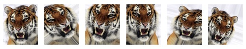

## 12 Double descent

- With neural networks, it seems better to have too many hidden units than too few.
- Likewise more hidden layers better than few.
- Running stochastic gradient descent till zero training error often gives good out-of-sample error.
- Increasing the number of units or layers and again training till zero error sometimes gives **even better** out-of-sample error.
- What happened to overfitting and the usual bias-variance trade-off?

Belkin, Hsu, Ma and Mandal (2018) *Reconciling Modern Machine Learning and the Bias-Variance Trade-off*. [arXiv](https://arxiv.org/abs/1812.11118)

### 12.1 Simulation study

- Model:
  $$y= \sin(x) + \epsilon$$
  with $x \sim$ Uniform(-5, 5) and $\epsilon$ is Gaussian with sd=0.3.
- Training set $n=20$, test set very large (10K).
- We fit a natural spline to the data with $d$ degrees of freedom, i.e., a linear regression onto $d$ basis functions
  $$\hat y_i = \hat \beta_1 N_1(x_i) + \hat \beta_2 N_2(x_i) + \cdots + \hat \beta_d N_d(x_i).$$
- When $d = 20$ we fit the training data exactly, and get all residuals equal to zero.
- When $d > 20$, we still fit the data exactly, but the solution is not unique. Among the zero-residual solutions, we pick the one with **minimum norm**, i.e. the zero-residual solution with smallest $\sum_{j=1}^d \hat \beta_j^2$.

[figure not shown]

Figure 14: Double descent phenomenon, illustrated using error plots for a one-dimensional natural spline example. The horizontal axis refers to the number of spline basis functions on the log scale. The training error hits zero when the degrees of freedom coincides with the sample size $n = 20$, the “interpolation threshold”, and remains zero thereafter. The test error increases dramatically at this threshold, but then descends again to a reasonable value before finally increasing again.

- When $d \le 20$, model is OLS, and we see usual bias-variance trade-off.
- When $d > 20$, we revert to minimum-norm solution. As $d$ increases above 20, $\sum_{j=1}^d \hat \beta_j^2$ **decreases** since it is easier to achieve zero error, and hence less wiggly solutions.

[figure not shown]

Figure 15: To achieve a zero-residual solution with $d = 20$ is a real stretch! Easier for larger $d$.

- Some facts.
  - In a wide linear model ($p \gg n$) fit by least squares, SGD with a small step size leads to a **minimum norm** zero-residual solution.
  - Stochastic gradient **flow**, i.e. the entire path of SGD solutions, is somewhat similar to ridge path.
  - By analogy, deep and wide neural networks fit by SGD down to zero training error often give good solutions that generalize well.
  - In particular cases with high **signal-to-noise ratio**, e.g., image recognition, are less prone to overfitting; the zero-error solution is mostly signal!